# analisis

```python
#carga de bibliotecas y de csv y excel
import pandas as pd

df_events = pd.read_csv('eventos_23_03_oslo.csv')
df_nobil = pd.read_excel('nobil_oslo_2022_connectors_flat.xlsx')
```

```python
#muestreo de variables
print("EVENTOS")
print(df_events.shape)
print(df_events.columns)
df_events.head()

print("\nNOBIL")
print(df_nobil.shape)
print(df_nobil.columns)
df_nobil.head()
```

```
EVENTOS
(35010, 13)
Index(['received_at', 'source_ts', 'record_key', 'station_id', 'charger_id',
       'connector_id', 'status', 'message_type', 'payload_json',
       'payload_sha1', 'derived', 'source_file', 'station_id_clean'],
      dtype='object')

NOBIL
(4099, 40)
Index(['station_id', 'international_id', 'name', 'lat', 'lon', 'position_raw',
       'street', 'house_number', 'zipcode', 'city', 'municipality',
       'municipality_id', 'county', 'created', 'updated',
       'number_charging_points', 'available_charging_points', 'station_status',
       'station_attr_open_24h', 'station_attr_real_time_information',
       'station_attr_public_funding', 'station_attr_parking_fee',
       'station_attr_time_limit', 'station_attr_location',
       'station_attr_availability', 'connector_attr_connector_id',
       'connector_attr_accessibility', 'connector_attr_connector',
       'connector_attr_charging_capacity', 'connector_attr_voltage_v',
       'connector_attr_vehicle_type', 'connector_attr_payment_method',
       'connector_attr_charge_mode', 'connector_attr_fixed_cable',
       'connector_attr_energy_carrier', 'connector_attr_evse_uid',
       'connector_attr_evse_id', 'connector_attr_amperage_a',
       'connector_attr_reservable', 'connector_attr_manufacturer'],
      dtype='object')
```

|  | station_id | international_id | name | lat | lon | position_raw | street | house_number | zipcode | city | ... | connector_attr_vehicle_type | connector_attr_payment_method | connector_attr_charge_mode | connector_attr_fixed_cable | connector_attr_energy_carrier | connector_attr_evse_uid | connector_attr_evse_id | connector_attr_amperage_a | connector_attr_reservable | connector_attr_manufacturer |
| --- | --- | --- | --- | --- | --- | --- | --- | --- | --- | --- | --- | --- | --- | --- | --- | --- | --- | --- | --- | --- | --- |
| 0 | 74759 | NOR_74759 | Recharge Filipstad | 59.910327 | 10.720555 | (59.910327,10.720555) | Filipstadkaia | NaN | 250 | OSLO | ... | Rechargeable cars and vans | Cellular phone and Charging card | Mode 4 | No | Electricity | EVSE UID | EVSE ID | Amperage (A) | NaN | NaN |
| 1 | 74759 | NOR_74759 | Recharge Filipstad | 59.910327 | 10.720555 | (59.910327,10.720555) | Filipstadkaia | NaN | 250 | OSLO | ... | Rechargeable cars and vans | Cellular phone and Charging card | Mode 4 | No | Electricity | EVSE UID | EVSE ID | Amperage (A) | NaN | NaN |
| 2 | 74759 | NOR_74759 | Recharge Filipstad | 59.910327 | 10.720555 | (59.910327,10.720555) | Filipstadkaia | NaN | 250 | OSLO | ... | Rechargeable cars and vans | Cellular phone and Charging card | Mode 4 | No | Electricity | EVSE UID | EVSE ID | Amperage (A) | NaN | NaN |
| 3 | 74759 | NOR_74759 | Recharge Filipstad | 59.910327 | 10.720555 | (59.910327,10.720555) | Filipstadkaia | NaN | 250 | OSLO | ... | Rechargeable cars and vans | Cellular phone and Charging card | Mode 4 | No | Electricity | EVSE UID | EVSE ID | Amperage (A) | NaN | NaN |
| 4 | 74759 | NOR_74759 | Recharge Filipstad | 59.910327 | 10.720555 | (59.910327,10.720555) | Filipstadkaia | NaN | 250 | OSLO | ... | Rechargeable cars and vans | Cellular phone and Charging card | Mode 4 | No | Electricity | EVSE UID | EVSE ID | Amperage (A) | NaN | NaN |

5 rows × 40 columns

```python
# Convertir la columna 'received_at' a formato datetime
df_events['received_at'] = pd.to_datetime(df_events['received_at'])
```

```python
# Verificar valores nulos en ambos DataFrames
df_events.isnull().sum()
df_nobil.isnull().sum()
```

```
station_id                               0
international_id                         0
name                                     0
lat                                      0
lon                                      0
position_raw                             0
street                                   0
house_number                           917
zipcode                                  0
city                                     0
municipality                             0
municipality_id                          0
county                                   0
created                                  0
updated                                  0
number_charging_points                   0
available_charging_points                0
station_status                           0
station_attr_open_24h                    0
station_attr_real_time_information       0
station_attr_public_funding           4030
station_attr_parking_fee                 0
station_attr_time_limit                  0
station_attr_location                    0
station_attr_availability                0
connector_attr_connector_id              0
connector_attr_accessibility             0
connector_attr_connector                 0
connector_attr_charging_capacity         0
connector_attr_voltage_v               406
connector_attr_vehicle_type              0
connector_attr_payment_method          172
connector_attr_charge_mode             255
connector_attr_fixed_cable             188
connector_attr_energy_carrier            0
connector_attr_evse_uid                430
connector_attr_evse_id                 430
connector_attr_amperage_a              402
connector_attr_reservable             3917
connector_attr_manufacturer           3986
dtype: int64
```

```python
# Verificar valores duplicados en ambos DataFrames
df_events.duplicated().sum()
df_nobil.duplicated().sum()
```

```
2237
```

```python
# Verificar duplicados en la columna 'station_id' de ambos DataFrames
print("Station_id duplicados en eventos:", df_events['station_id'].duplicated().sum())
print("Station_id duplicados en nobil:", df_nobil['station_id'].duplicated().sum())
```

```
Station_id duplicados en eventos: 33822
Station_id duplicados en nobil: 2739
```

```python
df_events = df_events.drop_duplicates()
```

```python
df_events.duplicated().sum()
```

```
0
```

```python
# Análisis de la variable 'status' en el DataFrame de eventos
df_events['status'].value_counts()
```

```
status
AVAILABLE     13249
CHARGING      10223
OUTOFORDER     6824
BLOCKED        4336
UNKNOWN         378
Name: count, dtype: int64
```

```python
# Análisis de la variable 'status' en el DataFrame de eventos (porcentaje)
df_events['status'].value_counts(normalize=True) * 100
```

```
status
AVAILABLE     37.843473
CHARGING      29.200229
OUTOFORDER    19.491574
BLOCKED       12.385033
UNKNOWN        1.079692
Name: proportion, dtype: float64
```

Se observa que, aunque un 37.8% de los cargadores se encuentran disponibles, existe un porcentaje significativo de puntos no operativos o bloqueados (aproximadamente un 32%), lo que puede afectar de forma considerable a la capacidad real de la red de carga.

Aunque la demanda de carga es elevada, la eficiencia del sistema se ve reducida por un elevado porcentaje de puntos no operativos o bloqueados, lo que sugiere que la capacidad teórica de la red no se corresponde con su capacidad real.

```python
# Extraer la hora de la columna 'received_at' y crear una nueva columna 'hour'
df_events['hour'] = df_events['received_at'].dt.hour
```

```python
df_hour_status = df_events.groupby(['hour', 'status']).size().unstack().fillna(0)
df_hour_status = df_hour_status.div(df_hour_status.sum(axis=1), axis=0)
df_hour_status
```

| status hour | AVAILABLE | BLOCKED | CHARGING | OUTOFORDER | UNKNOWN |
| --- | --- | --- | --- | --- | --- |
| 0 | 0.317942 | 0.036939 | 0.240106 | 0.397098 | 0.007916 |
| 1 | 0.305164 | 0.025039 | 0.266041 | 0.397496 | 0.006260 |
| 2 | 0.327808 | 0.053407 | 0.257827 | 0.359116 | 0.001842 |
| 3 | 0.294212 | 0.070740 | 0.294212 | 0.331190 | 0.009646 |
| 4 | 0.335731 | 0.081535 | 0.245803 | 0.330935 | 0.005995 |
| 5 | 0.374517 | 0.176834 | 0.256371 | 0.183784 | 0.008494 |
| 6 | 0.423973 | 0.188124 | 0.230300 | 0.137070 | 0.020533 |
| 7 | 0.380358 | 0.159523 | 0.284862 | 0.160608 | 0.014650 |
| 8 | 0.376812 | 0.134433 | 0.306347 | 0.178911 | 0.003498 |
| 9 | 0.391906 | 0.115016 | 0.296060 | 0.191693 | 0.005325 |
| 10 | 0.392481 | 0.131830 | 0.308772 | 0.157393 | 0.009524 |
| 11 | 0.383333 | 0.134444 | 0.315556 | 0.157778 | 0.008889 |
| 12 | 0.386691 | 0.127698 | 0.300360 | 0.169664 | 0.015588 |
| 13 | 0.400000 | 0.133166 | 0.312060 | 0.147739 | 0.007035 |
| 14 | 0.434897 | 0.140749 | 0.269373 | 0.143911 | 0.011070 |
| 15 | 0.394444 | 0.121212 | 0.307576 | 0.145455 | 0.031313 |
| 16 | 0.399304 | 0.132908 | 0.298317 | 0.157864 | 0.011608 |
| 17 | 0.391058 | 0.131612 | 0.313602 | 0.147355 | 0.016373 |
| 18 | 0.345776 | 0.124427 | 0.369352 | 0.151932 | 0.008513 |
| 19 | 0.335085 | 0.121551 | 0.386334 | 0.142576 | 0.014455 |
| 20 | 0.374732 | 0.120628 | 0.335475 | 0.159886 | 0.009279 |
| 21 | 0.378735 | 0.129174 | 0.297012 | 0.188049 | 0.007030 |
| 22 | 0.367347 | 0.103013 | 0.209913 | 0.317784 | 0.001944 |
| 23 | 0.345478 | 0.051399 | 0.187378 | 0.414444 | 0.001301 |

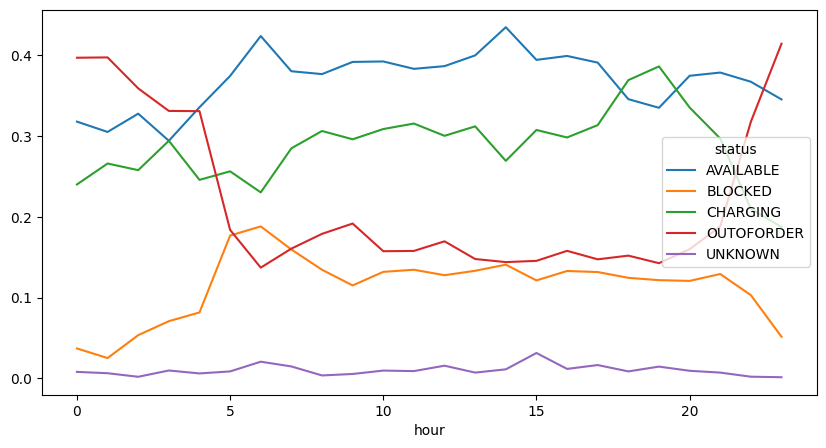

```python
df_hour_status.plot(figsize=(10,5))
```

Se observa un incremento progresivo de la actividad de carga a lo largo del día, alcanzando su máximo en horas de la tarde (18:00–20:00), lo que sugiere un patrón de uso vinculado al final de la jornada laboral

A pesar de existir una disponibilidad relativamente alta durante gran parte del día, la demanda en horas punta provoca una reducción significativa de los puntos libres, evidenciando posibles situaciones de saturación en determinados momentos

La presencia constante de estados BLOCKED sugiere un uso ineficiente de los puntos de carga, posiblemente debido a ocupación indebida de plazas o tiempos prolongados de estacionamiento sin carga activa

```python
# Análisis de la variable 'number_charging_points' en el DataFrame de nobil
df_nobil['number_charging_points'].describe()
```

```
count    4099.000000
mean       14.478165
std        27.066594
min         1.000000
25%         2.000000
50%         2.000000
75%        12.000000
max       120.000000
Name: number_charging_points, dtype: float64
```

Aunque la media de puntos de carga por estación es de aproximadamente 14, la mediana se sitúa en 2, lo que indica una distribución altamente sesgada. Esto sugiere que la mayoría de estaciones tienen baja capacidad, mientras que unas pocas concentran un gran número de puntos de carga.

La heterogeneidad en la capacidad de las estaciones puede generar desequilibrios en la utilización del sistema, con estaciones pequeñas más propensas a saturación y estaciones grandes con mayor capacidad de absorción de demanda

```python
# Análisis de la variable 'number_charging_points' en el DataFrame de nobil (frecuencia)
df_nobil['number_charging_points'].value_counts().head(10)
```

```
number_charging_points
2      2254
16      144
10      140
12      132
120     120
8       120
6       108
95       95
1        92
18       90
Name: count, dtype: int64
```

El análisis muestra que la mayoría de las estaciones cuentan únicamente con dos puntos de carga, lo que limita significativamente su capacidad operativa. En contraste, existe un pequeño número de estaciones con una alta concentración de cargadores, lo que confirma una distribución altamente desigual de la infraestructura

La elevada proporción de estaciones con baja capacidad puede explicar los niveles observados de ocupación y bloqueo, ya que estas estaciones son más susceptibles a saturarse ante incrementos en la demanda

```python
# Verificar cuántos 'station_id' únicos en df_events están presentes en df_nobil
df_events['station_id'].nunique()
df_nobil['station_id'].nunique()
```

```
1360
```

```python
# Verificar cuántos 'station_id' únicos en df_events están presentes en df_nobil, establecimientos de coincidiencia
len(set(df_events['station_id_clean']).intersection(set(df_nobil['station_id'])))
```

```
1188
```

```python
#Unificación de ambos DataFrames utilizando un merge
df_merged = df_events.merge(
    df_nobil,
    left_on='station_id_clean',
    right_on='station_id',
    how='left'
)
```

```python
df_merged.shape
```

```
(281115, 54)
```

```python
df_merged[['station_id_clean', 'station_id_x', 'station_id_y']].head()
```

|  | station_id_clean | station_id_x | station_id_y |
| --- | --- | --- | --- |
| 0 | 72338 | NOR_72338 | 72338 |
| 1 | 72338 | NOR_72338 | 72338 |
| 2 | 72338 | NOR_72338 | 72338 |
| 3 | 72338 | NOR_72338 | 72338 |
| 4 | 72338 | NOR_72338 | 72338 |

```python
df_merged['is_charging'] = df_merged['status'] == 'CHARGING'
```

```python
df_merged[['status', 'is_charging']].head()
```

|  | status | is_charging |
| --- | --- | --- |
| 0 | AVAILABLE | False |
| 1 | AVAILABLE | False |
| 2 | AVAILABLE | False |
| 3 | AVAILABLE | False |
| 4 | AVAILABLE | False |

```python
#¿Las estaciones con más cargadores tienen menos saturación?
ocupacion_estacion = df_merged.groupby('station_id_clean')['is_charging'].mean()
ocupacion_estacion.head()
```

```
station_id_clean
11265    0.200000
11285    0.500000
11289    0.500000
11297    0.500000
11299    0.142857
Name: is_charging, dtype: float64
```

```python
#   Capacidad de cada estación (número de puntos de carga)
capacidad_estacion = df_nobil.groupby('station_id')['number_charging_points'].first()

df_analysis = pd.DataFrame({
    'ocupacion': ocupacion_estacion,
    'capacidad': capacidad_estacion
})
```

```python
# Eliminar filas con valores nulos en el DataFrame de análisis
df_analysis = df_analysis.dropna()
```

```python
# Análisis del DataFrame de análisis
df_analysis.head()
df_analysis.shape
```

```
(1188, 2)
```

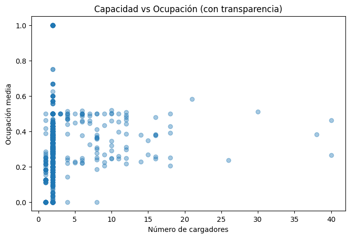

```python
# Visualización de la relación entre capacidad y ocupación
plt.figure(figsize=(8,5))
plt.scatter(df_analysis['capacidad'], df_analysis['ocupacion'], alpha=0.4)
plt.xlabel('Número de cargadores')
plt.ylabel('Ocupación media')
plt.title('Capacidad vs Ocupación (con transparencia)')
plt.show()
```

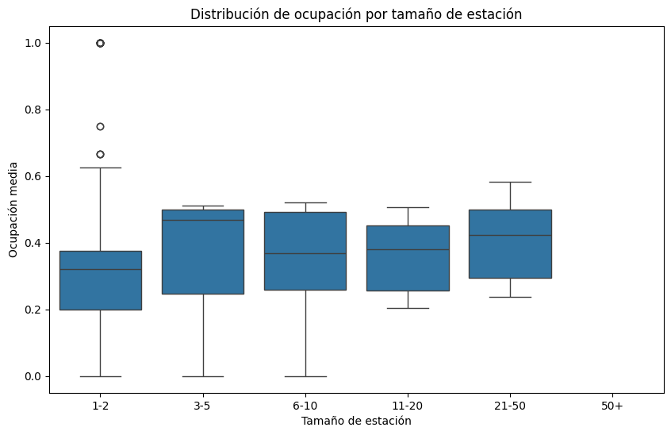

```python
# Visualización de la relación entre capacidad y ocupación utilizando un boxplot
import seaborn as sns
import matplotlib.pyplot as plt

plt.figure(figsize=(10,6))
sns.boxplot(x='capacidad_grupo', y='ocupacion', data=df_analysis)

plt.xlabel('Tamaño de estación')
plt.ylabel('Ocupación media')
plt.title('Distribución de ocupación por tamaño de estación')

plt.show()
```

Este comportamiento sugiere que la demanda de carga se ajusta a la capacidad disponible, manteniendo niveles de ocupación similares tanto en estaciones pequeñas como en estaciones de mayor tamaño

Las estaciones con menor número de cargadores presentan una mayor variabilidad en su ocupación, lo que indica una mayor susceptibilidad a episodios de saturación o infrautilización. En cambio, las estaciones de mayor tamaño muestran un comportamiento más estable

El análisis conjunto sugiere que, aunque la ocupación media es similar entre estaciones de distinto tamaño, la eficiencia del sistema se ve condicionada por factores como la variabilidad en estaciones pequeñas y la elevada proporción de puntos fuera de servicio o bloqueados. Esto indica que la capacidad instalada no es el único determinante del rendimiento de la red, siendo necesario considerar también aspectos operativos y de gestión

El hecho de que las estaciones de mayor capacidad presenten niveles de ocupación similares a las estaciones pequeñas sugiere que su ubicación podría estar asociada a zonas de mayor demanda. Esto indicaría una posible planificación estratégica de la infraestructura, donde las estaciones de mayor tamaño se sitúan en ubicaciones con mayor intensidad de uso

Desde una perspectiva económica, resulta razonable suponer que la instalación de estaciones de gran capacidad se realiza en zonas con alta demanda esperada, debido al mayor coste asociado. Esto refuerza la hipótesis de que la distribución de la infraestructura responde a criterios de optimización del uso

```python
# Crear una nueva columna 'no_disponible' que indique si el estado es 'OUTOFORDER' o 'BLOCKED'
df_merged['no_disponible'] = df_merged['status'].isin(['OUTOFORDER', 'BLOCKED'])
```

```python
df_merged[['status', 'no_disponible']].head()
```

|  | status | no_disponible |
| --- | --- | --- |
| 0 | AVAILABLE | False |
| 1 | AVAILABLE | False |
| 2 | AVAILABLE | False |
| 3 | AVAILABLE | False |
| 4 | AVAILABLE | False |

```python
# Estaciones con mayor porcentaje de tiempo no disponibles
problemas_estacion = df_merged.groupby('station_id_clean')['no_disponible'].mean()
problemas_estacion.head()
```

```
station_id_clean
11265    0.200000
11285    0.000000
11289    0.000000
11297    0.000000
11299    0.285714
Name: no_disponible, dtype: float64
```

```python
# Estaciones con mayor porcentaje de tiempo no disponibles
problemas_estacion.sort_values(ascending=False).head(10)
```

```
station_id_clean
65012    1.000000
53173    1.000000
52388    1.000000
52929    1.000000
52634    0.666667
52707    0.666667
52572    0.666667
52036    0.666667
52522    0.666667
52771    0.666667
Name: no_disponible, dtype: float64
```

```python
df_analysis['problemas'] = problemas_estacion
df_analysis = df_analysis.dropna()
```

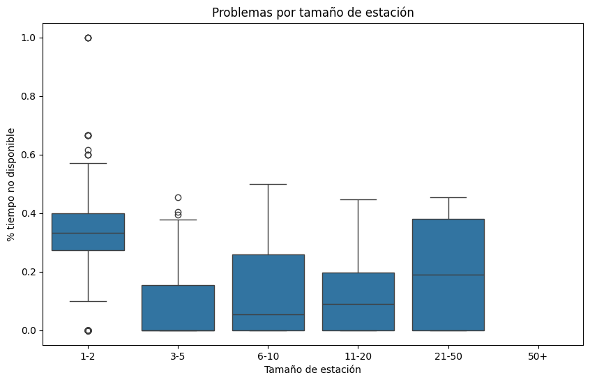

```python
import seaborn as sns
import matplotlib.pyplot as plt

plt.figure(figsize=(10,6))
sns.boxplot(x='capacidad_grupo', y='problemas', data=df_analysis)

plt.xlabel('Tamaño de estación')
plt.ylabel('% tiempo no disponible')
plt.title('Problemas por tamaño de estación')

plt.show()
```

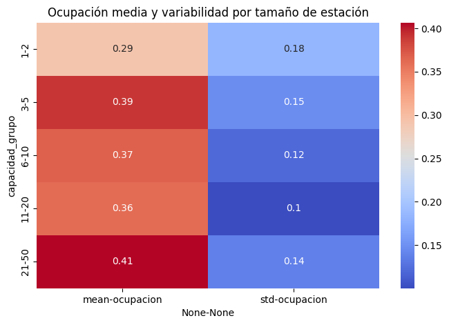

```python
pivot = df_analysis.pivot_table(
    values='ocupacion',
    index='capacidad_grupo',
    aggfunc=['mean', 'std']
)

import seaborn as sns
import matplotlib.pyplot as plt

plt.figure(figsize=(8,5))
sns.heatmap(pivot, annot=True, cmap='coolwarm')

plt.title('Ocupación media y variabilidad por tamaño de estación')
plt.show()
```

Se observa que las estaciones de mayor tamaño presentan, en promedio, una mayor ocupación, lo que sugiere que se sitúan en zonas de mayor demanda. Por otro lado, las estaciones más pequeñas no solo presentan menor ocupación media, sino también una mayor variabilidad, lo que indica un comportamiento más inestable y menos predecible

```python
# Análisis de tipos de cargadores
df_merged['tipo_cargador'] = df_merged['connector_attr_charging_capacity']
df_merged[['tipo_cargador']].value_counts().head()
```

```
tipo_cargador
400 kW DC                        68352
300 kW DC                        46860
250 kW DC                        44248
7,4 kW - 230V 1-phase max 32A    29954
62,5 kW DC                       23532
Name: count, dtype: int64
```

```python
ocupacion_tipo = df_merged.groupby('tipo_cargador')['is_charging'].mean()
ocupacion_tipo.sort_values(ascending=False)
```

```
tipo_cargador
500 kW DC                        0.500000
225 kW DC                        0.478824
250 kW DC                        0.465196
75 kW DC                         0.458853
180 kW DC                        0.454545
11 kW - 400V 3-phase max 16A     0.420840
100 kW - 500VDC max 200A         0.391564
200 kW DC                        0.376182
150 kW DC                        0.338076
50 kW - 500VDC max 100A          0.335586
3,6 kW - 230V 1-phase max 16A    0.320827
22 kW - 400V 3-phase max 32A     0.314651
20 kW - 500VDC max 50A           0.306122
300 kW DC                        0.299637
400 kW DC                        0.274915
7,4 kW - 230V 1-phase max 32A    0.260767
62,5 kW DC                       0.260581
350 kW DC                        0.250000
Name: is_charging, dtype: float64
```

Se observa una tendencia general a una mayor ocupación en varios tipos de cargadores rápidos en corriente continua (DC), lo que sugiere una preferencia de uso por infraestructuras de mayor potencia. No obstante, esta relación no es completamente uniforme y debe interpretarse teniendo en cuenta el volumen de observaciones de cada tipo de cargador

```python
conteo_tipo = df_merged['tipo_cargador'].value_counts()
tipos_frecuentes = conteo_tipo[conteo_tipo >= 1000].index

ocupacion_tipo_filtrada = (
    df_merged[df_merged['tipo_cargador'].isin(tipos_frecuentes)]
    .groupby('tipo_cargador')['is_charging']
    .mean()
    .sort_values(ascending=False)
)

ocupacion_tipo_filtrada
```

```
tipo_cargador
250 kW DC                        0.465196
11 kW - 400V 3-phase max 16A     0.420840
100 kW - 500VDC max 200A         0.391564
200 kW DC                        0.376182
150 kW DC                        0.338076
50 kW - 500VDC max 100A          0.335586
3,6 kW - 230V 1-phase max 16A    0.320827
22 kW - 400V 3-phase max 32A     0.314651
300 kW DC                        0.299637
400 kW DC                        0.274915
7,4 kW - 230V 1-phase max 32A    0.260767
62,5 kW DC                       0.260581
Name: is_charging, dtype: float64
```

```python
import re

def extraer_kw(texto):
    match = re.search(r'(\d+([.,]\d+)?)\s*kW', str(texto))
    if match:
        return float(match.group(1).replace(',', '.'))
    return None

df_analysis_tipo = ocupacion_tipo_filtrada.reset_index()
df_analysis_tipo['kw'] = df_analysis_tipo['tipo_cargador'].apply(extraer_kw)
```

```python
df_analysis_tipo.head()
```

|  | tipo_cargador | is_charging | kw |
| --- | --- | --- | --- |
| 0 | 250 kW DC | 0.465196 | 250.0 |
| 1 | 11 kW - 400V 3-phase max 16A | 0.420840 | 11.0 |
| 2 | 100 kW - 500VDC max 200A | 0.391564 | 100.0 |
| 3 | 200 kW DC | 0.376182 | 200.0 |
| 4 | 150 kW DC | 0.338076 | 150.0 |

```python
df_analysis_tipo = df_analysis_tipo.sort_values(by='kw')
```

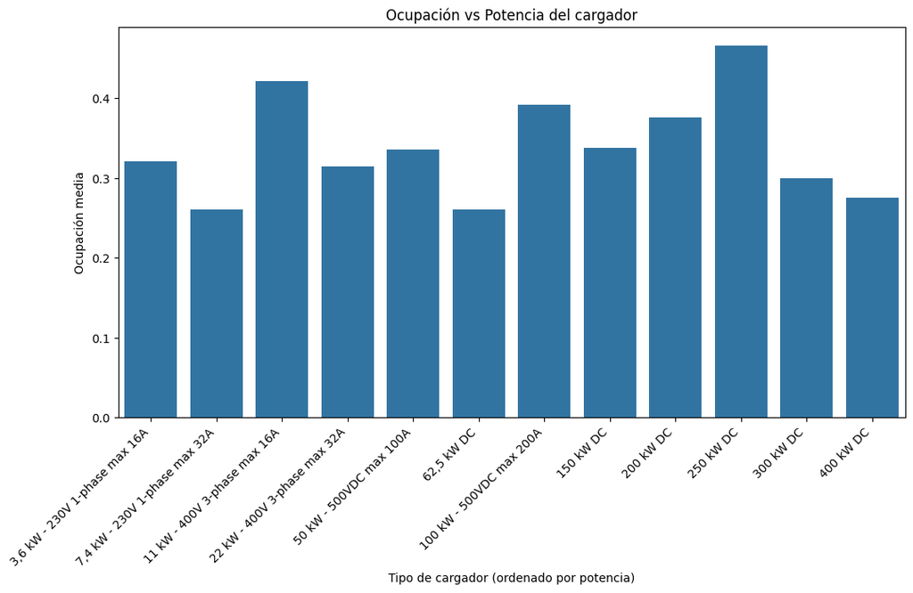

```python
import matplotlib.pyplot as plt
import seaborn as sns

plt.figure(figsize=(12,6))

sns.barplot(
    x=df_analysis_tipo['tipo_cargador'],
    y=df_analysis_tipo['is_charging']
)

plt.xticks(rotation=45, ha='right')
plt.ylabel('Ocupación media')
plt.xlabel('Tipo de cargador (ordenado por potencia)')
plt.title('Ocupación vs Potencia del cargador')

plt.show()
```

El análisis no muestra una relación creciente entre la potencia del cargador y su nivel de ocupación, lo que indica que la demanda no depende únicamente de la capacidad técnica del punto de carga

Esto sugiere que factores como la ubicación, accesibilidad o tipo de uso del cargador pueden tener un mayor impacto en la demanda que la potencia en sí misma

En conjunto, el análisis evidencia que la potencia del cargador no es un predictor suficiente del nivel de uso, por lo que resulta necesario considerar variables adicionales para modelizar la demanda de forma precisa

```python
# Análisis de la relación entre ocupación y problemas
ocupacion_estacion.describe()
```

```
count    1188.000000
mean        0.297843
std         0.180431
min         0.000000
25%         0.200000
50%         0.333333
75%         0.384615
max         1.000000
Name: is_charging, dtype: float64
```

La elevada variabilidad en la ocupación entre estaciones sugiere que la red no presenta un comportamiento homogéneo, existiendo diferencias significativas en el nivel de uso entre ubicaciones

```python
# estaciones infrautilizadas
bajas = (ocupacion_estacion < 0.2).sum()

# estaciones saturadas
altas = (ocupacion_estacion > 0.8).sum()

bajas, altas
```

```
(265, 24)
```

Se observa que aproximadamente un 22% de las estaciones presentan niveles muy bajos de ocupación, lo que indica una infrautilización significativa de parte de la red. En contraste, solo un pequeño porcentaje (en torno al 2%) muestra niveles de ocupación cercanos a la saturación

Se observa que aproximadamente un 22% de las estaciones presentan niveles muy bajos de ocupación, lo que indica una infrautilización significativa de parte de la red. En contraste, solo un pequeño porcentaje (en torno al 2%) muestra niveles de ocupación cercanos a la saturación

```python
df_mapa = df_nobil.groupby('station_id').agg({
    'lat': 'first',
    'lon': 'first',
    'number_charging_points': 'first'
}).reset_index()
```

```python
import folium

# centro de Oslo
mapa = folium.Map(location=[59.91, 10.75], zoom_start=12)
```

```python
for _, row in df_mapa.iterrows():
    folium.CircleMarker(
        location=[row['lat'], row['lon']],
        radius=row['number_charging_points'] * 0.2,  # tamaño según cargadores
        popup=f"Cargadores: {row['number_charging_points']}",
        color='blue',
        fill=True,
        fill_opacity=0.6
    ).add_to(mapa)

mapa
```

Make this Notebook Trusted to load map: File -> Trust Notebook

[interactive chart not shown]

```python
mapa.save("mapa_oslo.html")
```

La distribución espacial de las estaciones sugiere una planificación basada en la demanda esperada, donde las zonas centrales concentran tanto mayor número como mayor capacidad de puntos de carga, mientras que las zonas periféricas presentan una cobertura más limitada

# CONCLUSIÓN

### Infraestructura

- Alta concentración de estaciones en el centro de Oslo
- Zonas periféricas con menor densidad de estaciones
- Estaciones grandes ubicadas en zonas estratégicas
- Distribución no uniforme orientada a la demanda

### Relación infraestructura – uso

- Mayor capacidad → mayor estabilidad
- Zonas centrales → mayor actividad
- Infraestructura bien dimensionada
- No hay desbalance crítico entre oferta y demanda

## Conclusión global

- Red de carga bien distribuida
- Capacidad ajustada a la demanda
- Base sólida para modelos predictivos

## Herramientas utilizadas

### Lenguaje

- Python

### Procesos realizados

- Limpieza de datos
- Filtrado de registros
- Análisis exploratorio (EDA)
- Visualización de datos
- Análisis espacial
- Comparación de datasets